# A Bayesian Analysis of My D&D Dice

Everett Robinson

October 3, 2017

# Introduction

My girlfriend and I have been attending a weekly Dungeons & Dragons night at a local board game cafe, which means that we have been thoroughly immersed in the superstition surrounding the dice. We have heard stories of unlikely strings of bad rolls that ultimately lead to the frustrated fellow adventurer performing the [salt water test](https://www.youtube.com/watch?v=VI3N4Qg-JZM) to see if the dice are balanced poorly. This test is really cool, and it certainly explains the physical mechanism for why a die will come up on some faces more than others, but it doesn’t tell you anything about the probabilities of rolling each face. Even with an off balance die, say a d20 that’s weighted in favour of rolling a twenty, we shouldn’t expect every normal roll on a hard surface to come up twenty. How frequently it comes up will presumably depend on the severity of the balance issue. As an aspiring data scientist I couldn’t help but think that a much better approach would be a Bayesian analysis for estimating the probability of rolling each face.

Normally I don’t care too much about such superstitions and just take the rolls as they come. I probably never would have implemented this Bayesian analysis, if not for the fact that I have developed a bit of a reputation for rolling high damage numbers on my d10 at our table. The curiosity has now gotten the better of me and I want better estimates of the true probabilities for my dice.

# Methodology

There are a couple different ways I can think of to assess if my dice are correctly balanced. I could always use a simple frequentist hypothesis test and set a null hypothesis of **p** being equal to the fair probability for each face. I could then roll the dice many times and see if the observed data provides enough evidence to reject that hypothesis that the dice is fair. This is a nice and simple approach, which would be straight forward to test using the multinomial or binomial distribution. But there are a couple of drawbacks to this approach that I can immediately think of:

1. It tells us nothing about what a better estimate of the probability for each face is; and
2. We will likely need a lot more data to achieve significance using this frequentist approach.

Instead, I think a Bayesian approach will be much more informative. We have a couple options available to us: We can use a numerical approach like MCMC, and compute the posterior distributions for each face that way. Or we can try to find an analytically tractable way of computing the posterior given a specific type of prior, called a conjugate prior. Luckily for us, there are two useful conjugate priors we will want to consider. They are the beta-binomial distribution, and the more general dirichlet-multinomial distribution. Ultimately I will end up using both of these in this analysis.

The dirichlet-multinomial model allows us to model an n-dimensional system of discrete events with varying probabilites that all sum to one. Essentially a dice. The beta-binomal model is a special case of the dirichlet-multinomial model in which n = 2, and it basically describes a coin. I feel that it is best to cover the simpler Beta distribution and the beta-binomial model before going into the more general Dirichlet distribution and dirichlet-multinomial model.

In our bayesian approach we get to start with a prior belief of what the probability of rolling a specific face of the die is, and then using a set of data from real rolls, we can update the distribution of probabilities for that face. The beta-binomial model is a special conjugate prior model in bayesian statistics, which is just a fancy way of saying that if we start with a beta distribution for the probability **p** of rolling a certain face of the dice, and then gather data that fits a binomial distribution, we can find a new beta distribution that describes the posterior probability of rolling that face.

The probability mass function of the binomial distribution is simply:

$$\frac{n!}{k!(n-k)!} p^k(1-p)^{n-k}$$

Where n is the total number of trials, k is the number of successes, and p is the probability of a success.

As for the beta-binomial model, I will skip the math and just assert that this rule for updating the probability distribution is simply:

$$Prior = Beta(\alpha 0,\beta 0)$$
$$Posterior = Beta(\alpha 0 + successes,\beta 0 + failures)$$

Where $\alpha 0$ and $\beta 0$ are parameters of our prior beta distribution, successes is the number of times we rolled our chosen face, and failures is the number of times we rolled any other face. This means that before we get started we need to determine a reasonable beta prior to use. Let’s consider the analysis of a twenty sided dice for the rest of this section. If we honestly knew nothing about dice, we might decide that any value of **p** is just as likely as the rest, and assign a uniform prior distribution. This can be achieved with $Beta(1,1)$:

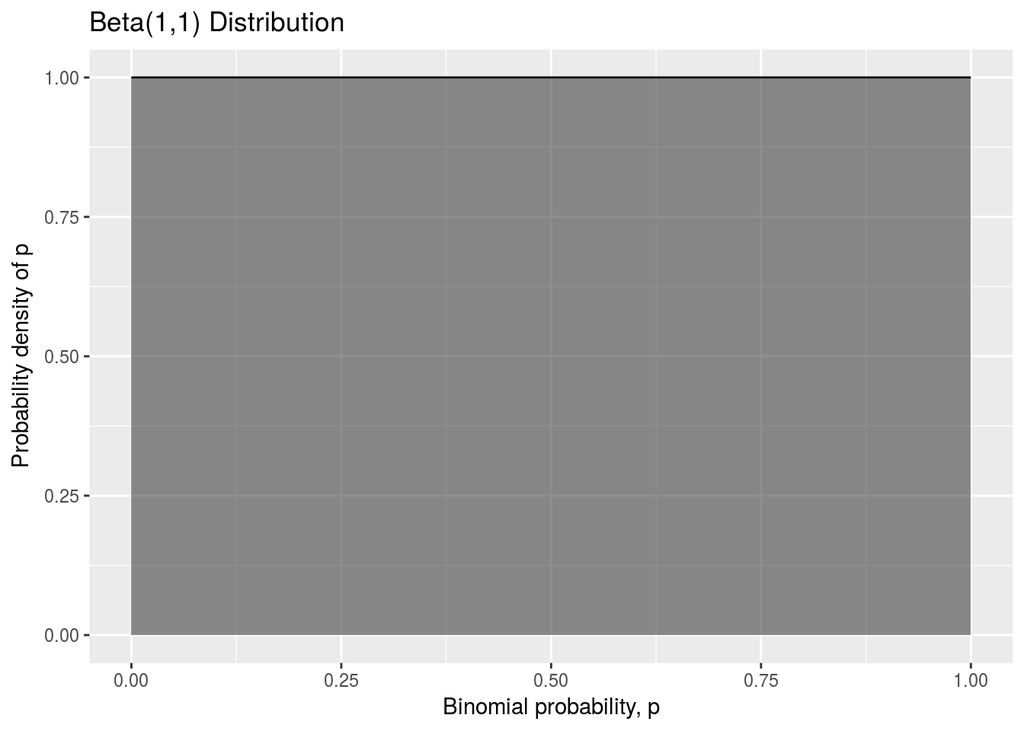

```r
ggplot(data.frame(x = c(0:1))) +
  stat_function(fun = dbeta,
                args = list(shape1 = 1, shape2 = 1)) +
  stat_function(fun = dbeta,
                args = list(shape1 = 1, shape2 = 1),
                xlim = c(0,1),
                geom = "area",
                aes(x, alpha = 0.5)) +
  labs(title = "Beta(1,1) Distribution",
       x = "Binomial probability, p",
       y = "Probability density of p") +
  theme(legend.position="none")
```

We will go forward assuming that we know a little bit about dice, and that our prior belief in the likelihood of any given face is based on the dice being fair. For our d20, this means we expect **p = 0.05**. To model this as a prior we could simply say that we expect 1 roll out of twenty to be our face, and model it with $Beta(1,19)$:

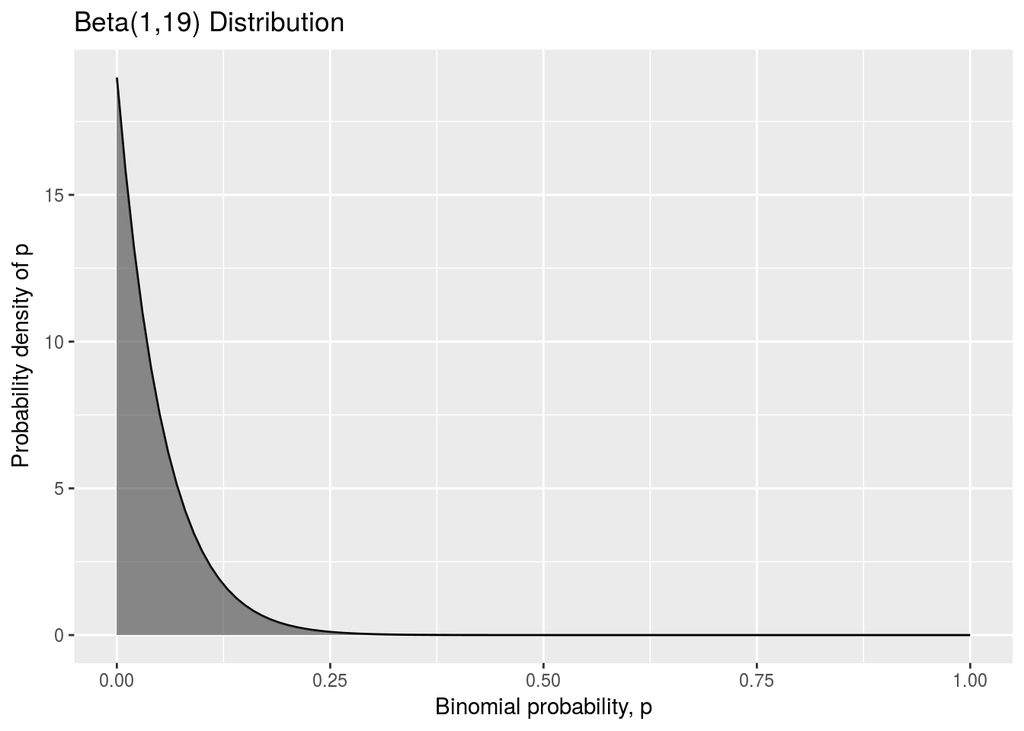

```r
ggplot(data.frame(x = c(0:1))) +
  stat_function(fun = dbeta,
                args = list(shape1 = 1, shape2 = 19)) +
  stat_function(fun = dbeta,
                args = list(shape1 = 1, shape2 = 19),
                xlim = c(0,1),
                geom = "area",
                aes(x, alpha = 0.5)) +
  labs(title = "Beta(1,19) Distribution",
       x = "Binomial probability, p",
       y = "Probability density of p") +
  theme(legend.position="none")
```

Notice that this isn’t a very confident prior distribution. We can see a decent likelihood for values of **p** anywhere between 0 and 0.25. If we want a stronger prior we can use larger values of $\alpha$ and $\beta$ where $\alpha / (\alpha + \beta) = 0.05$. Let’s look at $Beta(5,95)$:

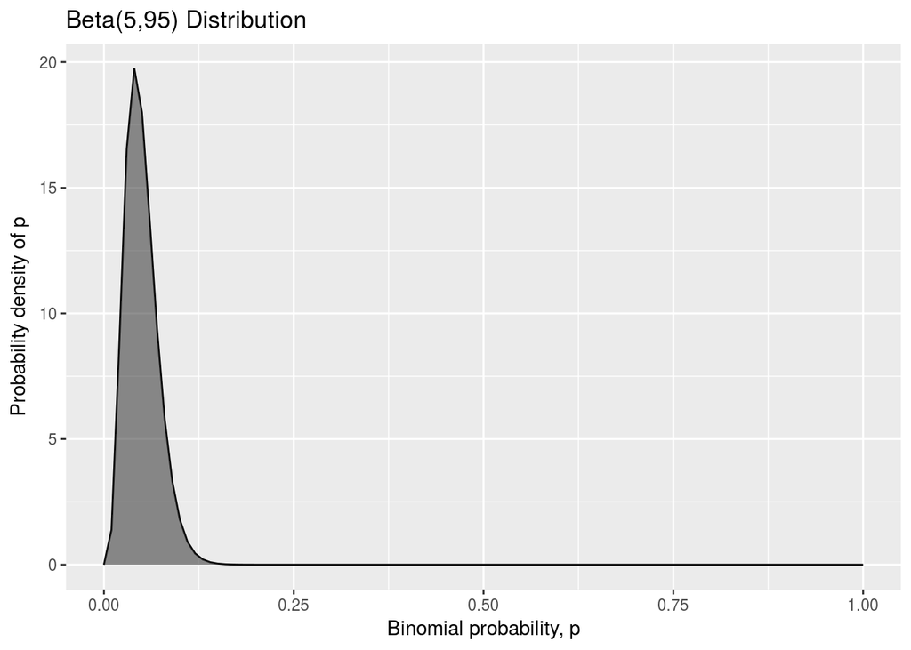

```r
ggplot(data.frame(x = c(0:1))) +
  stat_function(fun = dbeta,
                args = list(shape1 = 5, shape2 = 95)) +
  stat_function(fun = dbeta,
                args = list(shape1 = 5, shape2 = 95),
                xlim = c(0,1),
                geom = "area",
                aes(x, alpha = 0.5)) +
  labs(title = "Beta(5,95) Distribution",
       x = "Binomial probability, p",
       y = "Probability density of p") +
  theme(legend.position="none")
```

That’s a bit better. There is a definite peak around **p = 0.05** with a much tighter spread. You may find it strange that we are going through all this effort just to maintain uncertainty about the value of p. Isn’t our goal to get more confident in the true probability of rolling a certain face? It seems counter intuitive, but the power of Bayesian statistics is that we can continually work with uncertainty in our estimates, and that we treat **p** as a probability density function rather than a point estimate. This is true in both the prior and the posterior. Think of it as a means of not just finding a new most likely value for p, but also finding our uncertainty in this estimate of p, so that we know what we aren’t sure of. If we wanted to find some common summary statistics for **p** from a beta distribution (either the prior or the posterior), we can do it with the following formulas and functions:

$$Mean = \frac{\alpha}{\alpha + \beta}$$